# Regression project - predicting developers salary

Edyta Pszczółkowska

05 09 2021

The presented project is a regression model based on the dataset obtained through a survey conducted among StackOverflow portal users. I will try to predict yearly income in US dollars with 31 explanatory variables of different type (numeric, ordinal, discrete and binary) concerning the responents’ basic demographic traits and answers to questions about their skills or career path. 3 methods will be implemented: ordinary least square model, k-nearest neighbors algorithm and random forests. As the conclusion I will summarize and compare basic performance measures of the models.

Such a model may be very useful especially for people who consider their future carrier path in IT industry. It may also explain the differences and indicate more valuable skills and knowledge of particular programming languages or frameworks which determine better developer’s earnings.

A long journey ahead of us, let us start!

###Loading the data and necessary packages…

##Removing unnecessary variables and handling NAs

The dataset is huge and has a lot of missing data. Therefore I will start ETL process by deleting unnecessary variables and afterwards look for the records which have too much NAs.

In the first step let’s remove the cases with NAs in the dependent variable which is “ConvertedComp” (reduction of cases by almost 50%)…

```r
data <- data[!is.na(data$ConvertedComp),]
```

… and also remove the columns which represent answers to the survey questions about using StackOverflow and regarding survey itself:

```r
data <- data[ , -which(names(data) %in% c("SurveyEase", "SurveyLength", "SOComm", "SOPartFreq",   "SOVisitFreq", "SOAccount", "NEWSOSites",  "WelcomeChange", "NEWOtherComms", "NEWOffTopic" ))]
```

I will also delete couple of variables storing answers to multiple choice questions, which are not that much significant in terms of determining developers salary and in the same time would be very problematic to decode all their possible answers into binary types. These are:

**In general, what drives you to look for a new job? Select all that apply** (12 options to choose from)

**When job searching, how do you learn more about a company? Select all that apply.** (6 options to choose from)

**Imagine that you are deciding between two job offers with the same compensation, benefits, and location. Of the following factors, which 3 are MOST important to you?** (11 options to choose from)

**When buying a new tool or software, how do you discover and research available solutions? Select all that apply.** (6 options to choose from, almost half of the answers empty)

**What do you do when you get stuck on a problem? Select all that apply.** (8 options to choose from)

**You search for a coding solution online and the first result link is purple because you already visited it. How do you feel?** (4 options to choose from)

```r
data$NEWJobHunt <- NULL
data$NEWJobHuntResearch <- NULL
data$JobFactors <- NULL
data$NEWPurchaseResearch <- NULL
data$NEWStuck <- NULL
data$NEWPurpleLink <- NULL
```

And there is also set of questions which refer to the company of the developer rather than to him/her and to their skills:

**Do you think your company has a good onboarding process? (By onboarding, we mean the structured process of getting you settled in to your new role at a company)**

**Does your company have a dedicated DevOps person?**

**How important is the practice of DevOps to scaling software development?**

```r
data$NEWOnboardGood <- NULL
data$NEWDevOpsImpt <- NULL
data$NEWDevOps <- NULL
```

**Which currency do you use day-to-day? If your answer is complicated, please pick the one you’re most comfortable estimating in.**

```r
length(table(data$CurrencyDesc))
```

```
## [1] 128
```

As there would be 128 levels of this variable, I will delete this variable (and also parallel column with currency symbols) - information about country is fair enough (e.g. in case of countries in euro zone it is much better for all of 19 of them to know the country instead of the currency) :

```r
data$CurrencySymbol <- NULL
data$CurrencyDesc <- NULL
```

**What is your current total compensation (salary, bonuses, and perks, before taxes and deductions), in $? Please enter a whole number in the box below, without any punctuation. If you are paid hourly, please estimate an equivalent weekly, monthly, or yearly salary. If you prefer not to answer, please leave the box empty.**

**Is that compensation weekly, monthly, or yearly?**

Those two questions represent columns represent variables “CompFrequency” and “CompTotal” which were used to create the dependent variable “ConvertedComp”, therefore are not needed anymore:

```r
data$CompFreq <- NULL
data$CompTotal <- NULL
```

And now let’s have a look how many missing variables there are in every remaining column:

```r
colSums(is.na(data)) %>%
  sort()
```

```
##                   Respondent                   MainBranch
##                            0                            0
##                     Hobbyist                ConvertedComp
##                            0                            0
##                      Country                   Employment
##                            0                           39
##                       JobSat                   Age1stCode
##                           55                           85
##                    YearsCode                 YearsCodePro
##                          126                          135
##                      DevType                  NEWOvertime
##                          389                          433
##                    NEWEdImpt                      OrgSize
##                          499                          541
##                      EdLevel                      JobSeek
##                          568                          978
##                  WorkWeekHrs           LanguageWorkedWith
##                         1098                         1309
##                        OpSys                     NEWLearn
##                         1521                         1944
##               UndergradMajor     NEWCollabToolsWorkedWith
##                         2528                         2569
##                       Gender           PlatformWorkedWith
##                         2629                         2784
##       LanguageDesireNextYear                        Trans
##                         2922                         3096
##                          Age                 PurchaseWhat
##                         4160                         4426
##       PlatformDesireNextYear                    Ethnicity
##                         4544                         4598
##           DatabaseWorkedWith                    Sexuality
##                         5000                         5388
## NEWCollabToolsDesireNextYear       DatabaseDesireNextYear
##                         5798                         8254
##           WebframeWorkedWith       MiscTechDesireNextYear
##                         8597                         9032
##           MiscTechWorkedWith       WebframeDesireNextYear
##                        10033                        10324
```

```r
data$MiscTechDesireNextYear <- NULL
data$MiscTechWorkedWith <- NULL
data$WebframeDesireNextYear <- NULL
data$WebframeWorkedWith <- NULL
data$DatabaseDesireNextYear <- NULL
```

And in the end of this part of the process I will sum up all NAs for each of the row and delete the most mysterious ones (and most useless in the same time):

```r
data$NAs <-rowSums(is.na(data))

table(data$NAs)
```

```
##
##     0     1     2     3     4     5     6     7     8     9    10    11    12
## 14607  9349  4368  2322  1102   748   429   232   160   113    62    66    57
##    13    14    15    16    17    18    19    20    21    22    23    26
##    21    85   261   432    89   202    36    10     1     1     2     1
```

```r
length(data$Respondent[data$NAs >10])
```

```
## [1] 1264
```

There are 1264 records which lack of answers to more than 10 out of 34 left questions/variables. As the dataset is big enough for the models, I will let them go:

```r
data <- data[data$NAs < 11, ]
table(data$NAs)
```

```
##
##     0     1     2     3     4     5     6     7     8     9    10
## 14607  9349  4368  2322  1102   748   429   232   160   113    62
```

```r
data$NAs <- NULL
```

Now my dataset is clear enough to work with, great.

##Preparation of the variables

Now I will inspect all the remaining variables which store the answers to the survey’s question (with the same order they were put in the survey).

**Which of the following options best describes you today? Here, by “developer” we mean "someone who writes code.**

```r
table(data$MainBranch)
```

```
##
##                                                I am a developer by profession
##                                                                         30457
## I am not primarily a developer, but I write code sometimes as part of my work
##                                                                          3035
```

```r
data$MainBranch <- as.factor(data$MainBranch)
sum(is.na(data$MainBranch))
```

```
## [1] 0
```

OK! Nothing to do more with this variable

**SURVEY QUESTION: Do you code as a hobby?**

```r
table(data$Hobbyist)
```

```
##
##    No   Yes
##  7720 25772
```

```r
data$Hobbyist <- as.factor(data$Hobbyist)
sum(is.na(data$Hobbyist))
```

```
## [1] 0
```

Well, given the number of professional developers it is a huge a surprise to have so many hobbyist in a dataset. Maybe forthcoming variables will give an answer to this puzzle…

**Which of the following best describes your current employment status?**

```r
table(data$Employment)
```

```
##
##                                   Employed full-time
##                                                29515
##                                   Employed part-time
##                                                 1008
## Independent contractor, freelancer, or self-employed
##                                                 2938
```

```r
sum(is.na(data$Employment))
```

```
## [1] 31
```

As all the other groups (including NA) are fairly small in comparison to respondents working full time, I will make this variable binary by dividing the sample into “employed full-time” and all the other:

```r
data$Employment[is.na(data$Employment)] <- "Other"

data$Employment[!(data$Employment) == "Employed full-time"] <- "Other"

table(data$Employment)
```

```
##
## Employed full-time              Other
##              29515               3977
```

```r
data$Employment <- as.factor(data$Employment)
```

**Where do you live?**

```r
sort(table(data$Country))
```

```
##
##                                    Belize
##                                         1
##                         Brunei Darussalam
##                                         1
##                              Burkina Faso
##                                         1
##                                   Grenada
##                                         1
##                                    Guinea
##                                         1
##                                   Lesotho
##                                         1
##                                    Malawi
##                                         1
##                                Mauritania
##                                         1
##                                    Monaco
##                                         1
##                                     Niger
##                                         1
##          Saint Vincent and the Grenadines
##                                         1
##                              Turkmenistan
##                                         1
##                                     Yemen
##                                         1
##                                   Andorra
##                                         2
##                                    Angola
##                                         2
##                                   Bahamas
##                                         2
##                                  Barbados
##                                         2
##                                     Benin
##                                         2
##                                    Guyana
##                                         2
##                                     Haiti
```

[output cut: 262 more lines]

```
##                                       792
##                                    France
##                                      1086
##                                    Brazil
##                                      1108
##                                    Canada
##                                      1303
##                                   Germany
##                                      2244
##                                     India
##                                      2509
##                            United Kingdom
##                                      2512
##                             United States
##                                      7916
```

Besides grouping the countries by continents/parts of the world, I will also divide them accoriding to their economy status. This is reasonable since the countries vary significantly in terms of development even if they are neighbors to each other (like South and North Korea).

Therefore I downloaded the most recent dataset of countries divided into 4 groups by their gross national income per capita (GNI per capita):

1. LOW-INCOME ECONOMIES ($1,045 OR LESS)
2. LOWER-MIDDLE INCOME ECONOMIES ($1,046 TO $4,095)
3. UPPER-MIDDLE-INCOME ECONOMIES ($4,096 TO $12,695)
4. HIGH-INCOME ECONOMIES ($12,696 OR MORE)

The same dataset contains also the division of the countries by parts of the world:

1. East Asia and Pacific
2. Europe and Central Asia
3. Latin America & the Caribbean
4. Middle East and North Africa
5. North America
6. South Asia
7. Sub-Saharan Africa

The source: https://datahelpdesk.worldbank.org/knowledgebase/articles/906519-world-bank-country-and-lending-groups

To merge those two datasets I have to unify the countries names, which was the most horrible thing I had to do to prepare the data (but now at least I know there is such a country like Eswatini/ Swaziland).

```r
countries_division <- read.csv("D:\\Edyta pliki\\DS\\II semestr\\ML1\\Countries.csv")




data$Country[data$Country == "Swaziland"] <- "Eswatini"
data$Country[data$Country == "Bahamas"] <- "Bahamas, The"
data$Country[data$Country == "Democratic Republic of the Congo"] <- "Congo, Dem. Rep."
data$Country[data$Country == "Egypt"] <- "Egypt, Arab Rep."
data$Country[data$Country == "Hong Kong (S.A.R.)"] <- "Hong Kong SAR, China"
data$Country[data$Country == "Viet Nam"] <- "Vietnam"
data$Country[data$Country == "United Republic of Tanzania"] <- "Tanzania"
data$Country[data$Country == "Iran"] <- "Iran, Islamic Rep."
data$Country[data$Country == "Venezuela, Bolivarian Republic of..."] <- "Venezuela, RB"
data$Country[data$Country == "Lao People's Democratic Republic"] <- "Lao PDR"
data$Country[data$Country == "Republic of Korea"] <- "Korea, Dem. People's Rep."
data$Country[data$Country == "South Korea"] <- "Korea, Rep."
data$Country[data$Country == "Kyrgyzstan"] <- "Kyrgyz Republic"
data$Country[data$Country == "Saint Vincent and the Grenadines"] <- "St. Vincent and the Grenadines"
data$Country[data$Country == "Republic of Moldova"] <- "Moldova"
data$Country[data$Country == "Slovakia"] <- "Slovak Republic"
data$Country[data$Country == "Taiwan"] <- "Taiwan, China"
data$Country[data$Country == "Yemen"] <- "Yemen, Rep."
data$Country[data$Country == "The former Yugoslav Republic of Macedonia"] <- "North Macedonia"


data  <- merge(data, countries_division, by.x = "Country", by.y = "Economy" , all.x = T)





table(data$Income.group)
```

```
##
##                             High income          Low income Lower middle income
##                  36               24131                 128                4650
## Upper middle income
##                4533
```

As the low income group is very small in comparison to the other ones, I will merge “low income” and “Lower middle income” into one group (“low income”). I will also assign proper order to the income levels.

```r
data$Income.group[data$Income.group == "Lower middle income"] <- "Low income"

data$Income.group <- factor(data$Income.group,  levels = c("Low income", "Upper middle income","High income"  ),  ordered = TRUE)
```

The mysterious 36 respondents without income group are from Venezuela (missing data in the downloaded table), I will assign them to low income countries on my own:

```r
data$Income.group[data$Country == "Venezuela, RB"] <- "Low income"
table(data$Income.group)
```

```
##
##          Low income Upper middle income         High income
##                4814                4533               24131
```

```r
table(data$Region)
```

```
##
##        East Asia & Pacific      Europe & Central Asia
##                       2052                      15070
##  Latin America & Caribbean Middle East & North Africa
##                       2314                        932
##              North America                 South Asia
##                       9219                       3194
##         Sub-Saharan Africa
##                        697
```

Sub-Saharan Africa and Middle East & North Africa are both relatively small in comparison to remaining groups therefore will be also merged:

```r
data$Region[data$Region == "Sub-Saharan Africa" | data$Region == "Middle East & North Africa"] <- "Africa"
data$Region <- as.factor(data$Region)

table(data$Region)
```

```
##
##                    Africa       East Asia & Pacific     Europe & Central Asia
##                      1629                      2052                     15070
## Latin America & Caribbean             North America                South Asia
##                      2314                      9219                      3194
```

```r
sum(is.na(data$Income.group))
```

```
## [1] 14
```

```r
sum(is.na(data$Region))
```

```
## [1] 14
```

The remaining 14 NAs in variable “region” and “income.group”, are the respondents who answered they come from “nomadic” areas. I assume it must be some low income african territory, so I will put them into proper groups:

```r
data$Region[data$Country == "Nomadic"] <- "Africa"
data$Income.group[data$Country == "Nomadic"] <- "Low income"
data$Country <- NULL


sum(is.na(data$Region))
```

```
## [1] 0
```

```r
sum(is.na(data$Income.group))
```

```
## [1] 0
```

**Which of the following best describes the highest level of formal education that you’ve completed?**

```r
table(data$EdLevel)
```

```
##
##                                                Associate degree (A.A., A.S., etc.)
##                                                                               1135
##                                     Bachelorâ\200\231s degree (B.A., B.S., B.Eng., etc.)
##                                                                              16244
##                                             I never completed any formal education
##                                                                                139
##                                  Masterâ\200\231s degree (M.A., M.S., M.Eng., MBA, etc.)
##                                                                               8372
##                                         Other doctoral degree (Ph.D., Ed.D., etc.)
##                                                                               1107
##                                                          Primary/elementary school
##                                                                                147
##                                                 Professional degree (JD, MD, etc.)
##                                                                                457
## Secondary school (e.g. American high school, German Realschule or Gymnasium, etc.)
##                                                                               1413
##                             Some college/university study without earning a degree
##                                                                               3951
```

```r
sum(is.na(data$EdLevel))
```

```
## [1] 527
```

I will rearrange the levels of this variable to make analysis more clear. I will also assign proper order of the levels:

1st (lowest) level: No edu/primary/secondary/NAs

NAs I never completed any formal education Primary/elementary school Secondary school (e.g. American high school, German Realschule or Gymnasium, etc.)

2nd level: associate/without degree

Associate degree (A.A., A.S., etc.) Some college/university study without earning a degree

3rd level: completed degree

Bachelor’s degree (B.A., B.S., B.Eng., etc.) Master’s degree (M.A., M.S., M.Eng., MBA, etc.) Professional degree (JD, MD, etc.) Other doctoral degree (Ph.D., Ed.D., etc.)

```r
data$EdLevel[data$EdLevel == "I never completed any formal education"] <- "1-No edu/primary/secondary/NAs"
data$EdLevel[data$EdLevel == "Primary/elementary school"] <- "1-No edu/primary/secondary/NAs"
data$EdLevel[data$EdLevel == "Secondary school (e.g. American high school, German Realschule or Gymnasium, etc.)"] <- "1-No edu/primary/secondary/NAs"
data$EdLevel[is.na(data$EdLevel)] <- "1-No edu/primary/secondary/NAs"



data$EdLevel[data$EdLevel == "Associate degree (A.A., A.S., etc.)"] <- "2-associate/without degree"
data$EdLevel[data$EdLevel == "Some college/university study without earning a degree"] <- "2-associate/without degree"


data$EdLevel[data$EdLevel == "Bachelorâ€™s degree (B.A., B.S., B.Eng., etc.)"] <- "3-completed degree"
data$EdLevel[data$EdLevel == "Masterâ€™s degree (M.A., M.S., M.Eng., MBA, etc.)"] <- "3-completed degree"
data$EdLevel[data$EdLevel == "Other doctoral degree (Ph.D., Ed.D., etc.)"] <- "3-completed degree"
data$EdLevel[data$EdLevel == "Professional degree (JD, MD, etc.)"] <- "3-completed degree"


table(data$EdLevel)
```

```
##
## 1-No edu/primary/secondary/NAs     2-associate/without degree
##                           2226                           5086
##             3-completed degree
##                          26180
```

```r
data$EdLevel <- factor(data$EdLevel,
                           # levels from lowest to highest
                           levels = c("1-No edu/primary/secondary/NAs", "2-associate/without degree","3-completed degree"  ),  ordered = TRUE)
```

**What was your primary field of study?**

```r
table(data$UndergradMajor)
```

```
##
##           A business discipline (such as accounting, finance, marketing, etc.)
##                                                                            794
##                  A health science (such as nursing, pharmacy, radiology, etc.)
##                                                                            124
##        A humanities discipline (such as literature, history, philosophy, etc.)
##                                                                            698
##                  A natural science (such as biology, chemistry, physics, etc.)
##                                                                           1451
##   A social science (such as anthropology, psychology, political science, etc.)
##                                                                            600
##   Another engineering discipline (such as civil, electrical, mechanical, etc.)
##                                                                           2834
##                Computer science, computer engineering, or software engineering
##                                                                          19365
## Fine arts or performing arts (such as graphic design, music, studio art, etc.)
##                                                                            488
##                                                       I never declared a major
##                                                                            227
##          Information systems, information technology, or system administration
##                                                                           2443
##                                                      Mathematics or statistics
##                                                                           1162
##                                                  Web development or web design
##                                                                            895
```

I will divide this group into those with IT formal background and not:

```r
data$UndergradMajor[data$UndergradMajor %in%  c("Web development or web design", "Information systems, information technology, or system administration", "Computer science, computer engineering, or software engineering") ]  <- "IT Background"

data$UndergradMajor[!data$UndergradMajor == "IT Background"] <- "other"
data$UndergradMajor[is.na(data$UndergradMajor)] <- "other"



data$UndergradMajor <- as.factor(data$UndergradMajor)
table(data$UndergradMajor)
```

```
##
## IT Background         other
##         22703         10789
```

```r
sum(is.na(data$UndergradMajor))
```

```
## [1] 0
```

```r
colSums(is.na(data)) %>%
  sort()
```

```
##                   Respondent                   MainBranch
##                            0                            0
##                     Hobbyist                ConvertedComp
##                            0                            0
##                      EdLevel                   Employment
##                            0                            0
##               UndergradMajor                       Region
##                            0                            0
##                 Income.group                       JobSat
##                            0                           43
##                   Age1stCode                    YearsCode
##                           73                          104
##                 YearsCodePro                  NEWOvertime
##                          113                          180
##           LanguageWorkedWith                      JobSeek
##                          184                          243
##                        OpSys                      DevType
##                          300                          354
##                    NEWEdImpt                      OrgSize
##                          438                          505
##                  WorkWeekHrs                     NEWLearn
##                          802                          912
##     NEWCollabToolsWorkedWith                       Gender
##                         1333                         1374
##           PlatformWorkedWith       LanguageDesireNextYear
##                         1568                         1757
##                        Trans                          Age
##                         1840                         2905
##                 PurchaseWhat       PlatformDesireNextYear
##                         3186                         3303
##                    Ethnicity           DatabaseWorkedWith
##                         3340                         3815
##                    Sexuality NEWCollabToolsDesireNextYear
##                         4128                         4545
```

**How important is a formal education, such as a university degree in computer science, to your career?**

```r
table(data$NEWEdImpt)
```

```
##
##               Critically important                   Fairly important
##                               2950                               8820
## Not at all important/not necessary                 Somewhat important
##                               5455                               8225
##                     Very important
##                               7604
```

```r
sum(is.na(data$NEWEdImpt))
```

```
## [1] 438
```

This is an order variable. I will lower the number of options and assign proper order of levels:

```r
data$NEWEdImpt[is.na(data$NEWEdImpt)] <- "Not at all important/not necessary/NA"
data$NEWEdImpt[data$NEWEdImpt == "Not at all important/not necessary"] <- "Not at all important/not necessary/NA"

data$NEWEdImpt[data$NEWEdImpt == "Somewhat important"] <- "Somewhat important/Fairly important"
data$NEWEdImpt[data$NEWEdImpt == "Fairly important"] <- "Somewhat important/Fairly important"

data$NEWEdImpt[data$NEWEdImpt == "Very important"] <- "Very/Critically important"
data$NEWEdImpt[data$NEWEdImpt == "Critically important"] <- "Very/Critically important"


data$NEWEdImpt <- factor(data$NEWEdImpt,
                           levels = c("Not at all important/not necessary/NA", "Somewhat important/Fairly important", "Very/Critically important"  ),  ordered = TRUE)
table(data$NEWEdImpt)
```

```
##
## Not at all important/not necessary/NA   Somewhat important/Fairly important
##                                  5893                                 17045
##             Very/Critically important
##                                 10554
```

```r
sum(is.na(data$NEWEdImpt))
```

```
## [1] 0
```

**Which of the following describe you? Please select all that apply.**

```r
head(data$DevType, 10)
```

```
##  [1] "Developer, back-end;Developer, front-end;Developer, full-stack;DevOps specialist;Product manager"
##  [2] "Academic researcher;Data or business analyst;Database administrator;Designer;Developer, back-end;Developer, front-end;Developer, full-stack;Developer, game or graphics;Product manager;Scientist;System administrator"
##  [3] "Developer, desktop or enterprise applications;System administrator"
##  [4] "Database administrator;Developer, back-end;Developer, front-end;Developer, full-stack"
##  [5] "Database administrator;Designer;Developer, back-end;Developer, desktop or enterprise applications;Developer, front-end;Developer, mobile"
##  [6] "Developer, back-end;Developer, front-end;Developer, full-stack"
##  [7] "Database administrator;Developer, back-end;Developer, front-end;Developer, mobile"
##  [8] "Database administrator;Developer, back-end;Developer, front-end;Developer, full-stack;Developer, mobile;Engineering manager;Senior executive/VP"
##  [9] "Academic researcher;Database administrator;Designer;Developer, back-end;Developer, desktop or enterprise applications;Developer, front-end;Developer, full-stack;Developer, QA or test"
## [10] "Designer;Developer, back-end;Developer, front-end"
```

Here the respondents had 23 options to choose from. As the only way to decode their answers would be creating 23 dummy variables for each of the alternative, it would introduce a huge chaos in the models. Therefore I will add a variable, which corresponds to the number of options the respondents marked. The more options they marked, the more areas of IT they specialize in. I will achieve this by counting the numbers of semicolon signs (;) which separates consecutive element of the set and add one. I will use the “str_count” function from the package “stringr”. Afterwards I delete all unnecessary columns:

```r
library(stringr)
data$DevType_count <- str_count(data$DevType, ";") + 1

data$DevType <- NULL
sum(is.na(data$DevType_count))
```

```
## [1] 354
```

```r
table(data$DevType_count)
```

```
##
##    1    2    3    4    5    6    7    8    9   10   11   12   13   14   15   16
## 8878 6730 6035 4229 2693 1779 1082  662  398  241  159   98   58   38   19   13
##   17   18   19   20   21   23
##    9    5    2    3    1    6
```

```r
data$DevType_count[is.na(data$DevType_count)] <- median(data$DevType_count < 18,  na.rm = TRUE)

data <- data[data$DevType_count < 18, ]
table(data$DevType_count)
```

```
##
##    1    2    3    4    5    6    7    8    9   10   11   12   13   14   15   16
## 9232 6730 6035 4229 2693 1779 1082  662  398  241  159   98   58   38   19   13
##   17
##    9
```

ANd let us see a distribution of the variable:

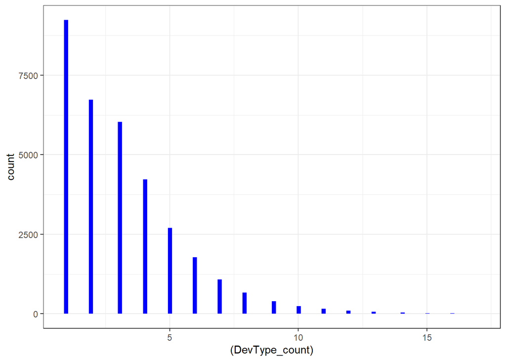

```r
ggplot(data,
       aes(x = (DevType_count))) +
  geom_histogram(fill = "blue",
                 bins = 100) +
  theme_bw()
```

**How satisfied are you with your current job? (If you work multiple jobs, answer for the one you spend the most hours on.)**

This variable is the order one, let’s arrange the proper values to its proper place in order:

```r
table(data$JobSat)
```

```
##
## Neither satisfied nor dissatisfied              Slightly dissatisfied
##                               3870                               5556
##                 Slightly satisfied                  Very dissatisfied
##                              10389                               2684
##                     Very satisfied
##                              10933
```

```r
sum(is.na(data$JobSat))
```

```
## [1] 43
```

As the number of people who gave no answer to this question is low, I will combine the neutral category and the NAs into “Neither satisfied nor dissatisfied/NAs” , all satisfied and dissatisfied (more and less) will be also merged together and afterwards assign proper order of the values will be assigned:

```r
data$JobSat[is.na(data$JobSat)] <- "Neither satisfied nor dissatisfied/NAs"
data$JobSat[data$JobSat == "Neither satisfied nor dissatisfied"] <- "Neither satisfied nor dissatisfied/NAs"
data$JobSat[data$JobSat == "Very dissatisfied"] <- "Dissatisfied"
data$JobSat[data$JobSat == "Slightly dissatisfied"] <- "Dissatisfied"
data$JobSat[data$JobSat == "Slightly satisfied"] <- "Satisfied"
data$JobSat[data$JobSat == "Very satisfied"] <- "Satisfied"



data$JobSat <- factor(data$JobSat, levels = c("Dissatisfied", "Neither satisfied nor dissatisfied/NAs", "Satisfied"  ),  ordered = TRUE)

table(data$JobSat)
```

```
##
##                           Dissatisfied Neither satisfied nor dissatisfied/NAs
##                                   8240                                   3913
##                              Satisfied
##                                  21322
```

```r
sum(is.na(data$JobSat))
```

```
## [1] 0
```

**Approximately how many people are employed by the company or organization you currently work for?**

This is an order variable, therefore I will set proper level order, but before combine NAs and freelancers into one, lowest group and make the number of options smaller:

```r
table(data$OrgSize)
```

```
##
##                           1,000 to 4,999 employees
##                                               3729
##                                 10 to 19 employees
##                                               3042
##                           10,000 or more employees
##                                               4661
##                               100 to 499 employees
##                                               6401
##                                   2 to 9 employees
##                                               3084
##                                 20 to 99 employees
##                                               7296
##                           5,000 to 9,999 employees
##                                               1361
##                               500 to 999 employees
##                                               2203
## Just me - I am a freelancer, sole proprietor, etc.
##                                               1196
```

```r
sum(is.na(data$OrgSize))
```

```
## [1] 502
```

```r
data$OrgSize[is.na(data$OrgSize)] <- "freelancer/NAs"
data$OrgSize[data$OrgSize == "Just me - I am a freelancer, sole proprietor, etc."] <- "freelancer/NAs"

data$OrgSize[data$OrgSize == "2 to 9 employees"] <- "up to 99 employees"
data$OrgSize[data$OrgSize == "10 to 19 employees"  ] <- "up to 99 employees"
data$OrgSize[data$OrgSize == "20 to 99 employees"  ] <- "up to 99 employees"

data$OrgSize[data$OrgSize == "100 to 499 employees"] <- "100 to 999 employees"
data$OrgSize[data$OrgSize == "500 to 999 employees"] <- "100 to 999 employees"

data$OrgSize[data$OrgSize == "1,000 to 4,999 employees"] <- "more than 1000 employees"
data$OrgSize[ data$OrgSize == "5,000 to 9,999 employees"  ] <- "more than 1000 employees"
data$OrgSize[data$OrgSize == "10,000 or more employees"  ] <- "more than 1000 employees"

data$OrgSize <- factor(data$OrgSize, levels = c("freelancer/NAs", "up to 99 employees", "100 to 999 employees", "more than 1000 employees" ),  ordered = TRUE)


table(data$OrgSize)
```

```
##
##           freelancer/NAs       up to 99 employees     100 to 999 employees
##                     1698                    13422                     8604
## more than 1000 employees
##                     9751
```

```r
sum(is.na(data$OrgSize))
```

```
## [1] 0
```

**On average, how many hours per week do you work? Please enter a whole number in the box.**

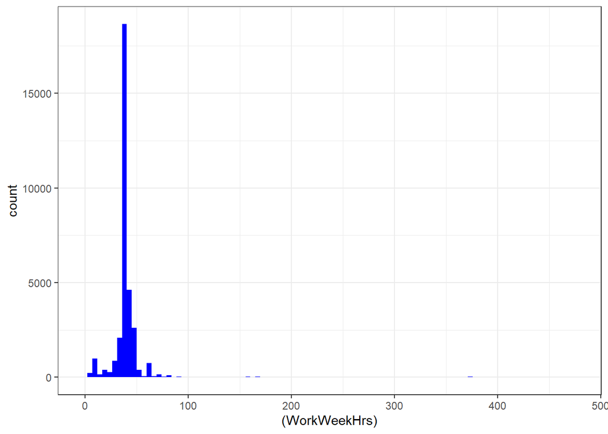

```r
ggplot(data,
       aes(x = (WorkWeekHrs))) +
  geom_histogram(fill = "blue",
                 bins = 100) +
  theme_bw()
```

What an imagination! As the whole week has 24*7 = 168 hours, I propose to censor the answers to maximum 112 (112 hours per week means working 16 hours per day) and replace NAs with the median value (firstly let’s check how many of them there are in the dataset):

```r
length(data$Respondent[data$WorkWeekHrs > 112])
```

[output not shown]

```r
sum(is.na(data$WorkWeekHrs))
```

```
## [1] 801
```

```r
median(data$WorkWeekHrs[data$WorkWeekHrs < 113], na.rm = TRUE)
```

```
## [1] 40
```

```r
data$WorkWeekHrs[data$WorkWeekHrs > 113 ] <- 112

data$WorkWeekHrs[ is.na(data$WorkWeekHrs) ] <- median(data$WorkWeekHrs, na.rm = TRUE)
```

Let’s check the distribution again:

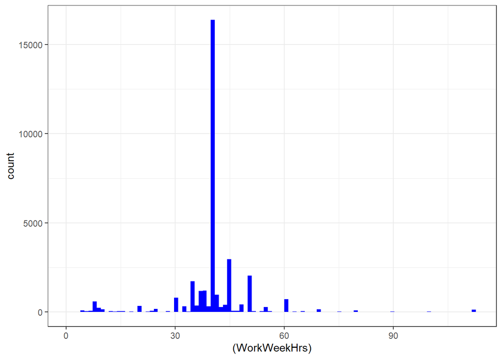

```r
ggplot(data,
       aes(x = (WorkWeekHrs))) +
  geom_histogram(fill = "blue",
                 bins = 100) +
  theme_bw()
```

**How often do you work overtime or beyond the formal time expectation of your job?**

```r
table(data$NEWOvertime)
```

```
##
##                                                    Never
##                                                     3647
## Occasionally: 1-2 days per quarter but less than monthly
##                                                     7471
##                         Often: 1-2 days per week or more
##                                                     8160
##                        Rarely: 1-2 days per year or less
##                                                     5053
##       Sometimes: 1-2 days per month but less than weekly
##                                                     8964
```

```r
sum(is.na(data$NEWOvertime))
```

```
## [1] 180
```

It is an order variable, so the levels must be ordered and their number limited:

```r
data$NEWOvertime[is.na(data$NEWOvertime)] <- "Unknown/Never/Rarely"
data$NEWOvertime[data$NEWOvertime == "Never"] <- "Unknown/Never/Rarely"
data$NEWOvertime[data$NEWOvertime == "Rarely: 1-2 days per year or less"] <- "Unknown/Never/Rarely"

data$NEWOvertime[data$NEWOvertime == "Occasionally: 1-2 days per quarter but less than monthly"] <- "Occasionally/Sometimes"
data$NEWOvertime[data$NEWOvertime == "Sometimes: 1-2 days per month but less than weekly"] <- "Occasionally/Sometimes"

data$NEWOvertime <- factor(data$NEWOvertime, levels = c("Unknown/Never/Rarely","Occasionally/Sometimes" , "Often: 1-2 days per week or more" ),  ordered = TRUE)


table(data$NEWOvertime)
```

```
##
##             Unknown/Never/Rarely           Occasionally/Sometimes
##                             8880                            16435
## Often: 1-2 days per week or more
##                             8160
```

```r
sum(is.na(data$NEWOvertime))
```

```
## [1] 0
```

**Which of the following best describes your current job-seeking status?**

```r
table(data$JobSeek)
```

```
##
##                                I am actively looking for a job
##                                                           4323
##                   I am not interested in new job opportunities
##                                                           9169
## Iâ\200\231m not actively looking, but I am open to new opportunities
##                                                          19740
```

```r
sum(is.na(data$JobSeek))
```

```
## [1] 243
```

For NAs we need special category:

```r
data$JobSeek[is.na(data$JobSeek)] <- "Unknown"



table(data$JobSeek)
```

```
##
##                                I am actively looking for a job
##                                                           4323
##                   I am not interested in new job opportunities
##                                                           9169
## Iâ\200\231m not actively looking, but I am open to new opportunities
##                                                          19740
##                                                        Unknown
##                                                            243
```

```r
sum(is.na(data$JobSeek))
```

```
## [1] 0
```

```r
data$JobSeek <- as.factor(data$JobSeek)
```

**How frequently do you learn a new language or framework?**

```r
table(data$NEWLearn)
```

```
##
##     Every few months        Once a decade          Once a year
##                10517                  675                12734
## Once every few years
##                 8638
```

```r
sum(is.na(data$NEWLearn))
```

```
## [1] 911
```

```r
data$NEWLearn[is.na(data$NEWLearn)] <- "Unknown"

data$NEWLearn <- factor(data$NEWLearn, levels = c("Unknown" , "Once a decade", "Once a year", "Once every few years", "Every few months"), ordered = TRUE)

table(data$NEWLearn)
```

```
##
##              Unknown        Once a decade          Once a year
##                  911                  675                12734
## Once every few years     Every few months
##                 8638                10517
```

```r
sum(is.na(data$NEWLearn))
```

```
## [1] 0
```

**Which database environments have you done extensive development work in over the past year, and which do you want to work in over the next year? (If you both worked with the database and want to continue to do so, please check both boxes in that row.)** (14 options)

**Which platforms have you done extensive development work in over the past year, and which do you want to work in over the next year? (If you both worked with the platform and want to continue to do so, please check both boxes in that row.)** (16 options)

**Which collaboration tools have you done extensive development work in over the past year, and which do you want to work in over the next year? (If you worked with the tool and want to continue to do so, please check both boxes in that row.)**(12 options)

The same story as before: creating dummy variables for all of them would be a data science student nightmare. I will use the same trick as before with kinds of developers, the same way I will keep a very valuable information: how wide the skills portfolio of a particular developer is and how ambitious they are about learning new things:

```r
data$DatabaseWorkedWith_count <- str_count(data$DatabaseWorkedWith, ";") +1
data$DatabaseWorkedWith <- NULL

table(data$DatabaseWorkedWith_count)
```

```
##
##    1    2    3    4    5    6    7    8    9   10   11   12   13   14
## 7742 7626 5815 3811 2255 1231  634  284  157   61   27   13    6    1
```

```r
sum(is.na(data$DatabaseWorkedWith_count))
```

```
## [1] 3812
```

Let’s replace NAs with median values:

```r
data$DatabaseWorkedWith_count[is.na(data$DatabaseWorkedWith_count)] <- median(data$DatabaseWorkedWith_count, na.rm = TRUE)
```

```r
data$LanguageDesireNextYear_count <- str_count(data$LanguageDesireNextYear, ";") +1
data$LanguageDesireNextYear <- NULL


table(data$LanguageDesireNextYear_count)
```

```
##
##    1    2    3    4    5    6    7    8    9   10   11   12   13   14   15   16
## 2813 4442 5531 5602 4755 3437 2207 1306  702  414  220  129   69   29   19   18
##   17   18   19   20   21   22   24   25
##    8    2    3    1    3    2    2    5
```

```r
sum(is.na(data$LanguageDesireNextYear_count))
```

```
## [1] 1756
```

```r
data$LanguageWorkedWith_count <- str_count(data$LanguageWorkedWith, ";") +1
data$LanguageWorkedWith <- NULL


table(data$LanguageWorkedWith_count)
```

```
##
##    1    2    3    4    5    6    7    8    9   10   11   12   13   14   15   16
## 1500 3320 4865 5954 5661 4403 2860 1835 1168  700  418  269  152   81   46   20
##   17   18   19   20   21   22   24   25
##   17    5    7    2    3    3    1    1
```

```r
sum(is.na(data$LanguageWorkedWith_count))
```

```
## [1] 184
```

Let’s replace NAs with median values:

```r
data$LanguageDesireNextYear_count[is.na(data$LanguageDesireNextYear_count)] <- median(data$LanguageDesireNextYear_count, na.rm = TRUE)

data$LanguageWorkedWith_count[is.na(data$LanguageWorkedWith_count)] <- median(data$LanguageWorkedWith_count, na.rm = TRUE)
```

```r
data$NEWCollabToolsDesireNextYear_count <- str_count(data$NEWCollabToolsDesireNextYear, ";") +1
data$NEWCollabToolsDesireNextYear <- NULL

table(data$NEWCollabToolsDesireNextYear_count)
```

```
##
##    1    2    3    4    5    6    7    8    9   10   11
## 4077 5963 6830 5556 3647 1743  721  255   76   28   37
```

```r
sum(is.na(data$NEWCollabToolsDesireNextYear_count))
```

```
## [1] 4542
```

```r
data$NEWCollabToolsWorkedWith_count <- str_count(data$NEWCollabToolsWorkedWith, ";") +1
data$NEWCollabToolsWorkedWith <- NULL


table(data$NEWCollabToolsWorkedWith_count)
```

```
##
##    1    2    3    4    5    6    7    8    9   10   11
## 2650 4400 5804 6422 5955 3836 2040  771  234   28    4
```

```r
sum(is.na(data$NEWCollabToolsWorkedWith_count))
```

```
## [1] 1331
```

Let’s replace NAs with median values:

```r
data$NEWCollabToolsDesireNextYear_count[is.na(data$NEWCollabToolsDesireNextYear_count)] <- median(data$NEWCollabToolsDesireNextYear_count, na.rm = TRUE)
data$NEWCollabToolsWorkedWith_count[is.na(data$NEWCollabToolsWorkedWith_count)] <- median(data$NEWCollabToolsWorkedWith_count, na.rm = TRUE)
```

```r
data$PlatformDesireNextYear_count <- str_count(data$PlatformDesireNextYear, ";") +1
data$PlatformDesireNextYear <- NULL


table(data$PlatformDesireNextYear_count)
```

```
##
##    1    2    3    4    5    6    7    8    9   10   11   12   13   14   15   16
## 4141 5470 5729 5008 3763 2511 1577  890  510  276  161   63   35   18   10   11
```

```r
sum(is.na(data$PlatformDesireNextYear_count))
```

```
## [1] 3302
```

```r
data$PlatformWorkedWith_count <- str_count(data$PlatformWorkedWith, ";") +1
data$PlatformWorkedWith <- NULL


table(data$PlatformWorkedWith_count)
```

```
##
##    1    2    3    4    5    6    7    8    9   10   11   12   13   14   15   16
## 5983 6858 6030 4802 3280 2096 1286  742  391  223  105   66   28   11    4    2
```

```r
sum(is.na(data$PlatformWorkedWith_count))
```

```
## [1] 1568
```

Let’s replace NAs with median values:

```r
data$PlatformDesireNextYear_count[is.na(data$PlatformDesireNextYear_count)] <- median(data$PlatformDesireNextYear_count, na.rm = TRUE)
data$PlatformWorkedWith_count[is.na(data$PlatformWorkedWith_count)] <- median(data$PlatformWorkedWith_count, na.rm = TRUE)
```

**What is the primary operating system in which you work?**

```r
table(data$OpSys)
```

```
##
##         BSD Linux-based       MacOS     Windows
##          20        8530        9783       14843
```

```r
sum(is.na(data$OpSys))
```

```
## [1] 299
```

I will combine BSD and NAs into one group:

```r
data$OpSys[data$OpSys == "BSD"] <- "BSD/Unknown"

data$OpSys[is.na(data$OpSys)]  <- "BSD/Unknown"


table(data$OpSys)
```

```
##
## BSD/Unknown Linux-based       MacOS     Windows
##         319        8530        9783       14843
```

```r
sum(is.na(data$OpSys))
```

```
## [1] 0
```

```r
data$OpSys <- as.factor(data$OpSys)
```

**What level of influence do you, personally, have over new technology purchases at your organization?**

Ordinal value, let’s rearrange the order:

```r
table(data$PurchaseWhat)
```

```
##
## I have a great deal of influence    I have little or no influence
##                             5277                            13205
##            I have some influence
##                            11812
```

```r
sum(is.na(data$PurchaseWhat))
```

```
## [1] 3181
```

```r
data$PurchaseWhat[is.na(data$PurchaseWhat)] <- "Unknown"
data$PurchaseWhat <- factor(data$PurchaseWhat, levels = c("Unknown", "I have little or no influence", "I have some influence", "I have a great deal of influence"), ordered = TRUE)
```

And now pure demographic questions:

**Which of the following describe you, if any? Please check all that apply. If you prefer not to answer, you may leave this question blank.**

```r
table(data$Gender)
```

```
##
##                                                         Man
##                                                       29421
##       Man;Non-binary, genderqueer, or gender non-conforming
##                                                          80
##           Non-binary, genderqueer, or gender non-conforming
##                                                         244
##                                                       Woman
##                                                        2269
##                                                   Woman;Man
##                                                          27
## Woman;Man;Non-binary, genderqueer, or gender non-conforming
##                                                           9
##     Woman;Non-binary, genderqueer, or gender non-conforming
##                                                          55
```

```r
sum(is.na(data$Gender))
```

```
## [1] 1370
```

I will combine this varibale into 3 groups: man, woman and other (including NAs):

```r
data$Gender[data$Gender == "Man;Non-binary, genderqueer, or gender non-conforming"] <- "other"
data$Gender[data$Gender == "Non-binary, genderqueer, or gender non-conforming"] <- "other"
data$Gender[data$Gender == "Woman;Man"] <- "other"
data$Gender[data$Gender == "Woman;Man;Non-binary, genderqueer, or gender non-conforming"] <- "other"
data$Gender[data$Gender == "Woman;Non-binary, genderqueer, or gender non-conforming"] <- "other"
data$Gender[is.na(data$Gender)] <- "other"

table(data$Gender)
```

```
##
##   Man other Woman
## 29421  1785  2269
```

```r
sum(is.na(data$Gender))
```

```
## [1] 0
```

```r
data$Gender <- as.factor(data$Gender)
```

**Are you transgender?**

```r
table(data$Trans)
```

```
##
##    No   Yes
## 31388   251
```

```r
sum(is.na(data$Trans))
```

```
## [1] 1836
```

As only 0,7% (near zero variance) respondents claim to be transsexual and there is a huge amount if NAs in this variable I will drop this column:

```r
data$Trans <- NULL
```

**Which of the following describe you, if any? Please check all that apply. If you prefer not to answer, you may leave this question blank.**

```r
table(data$Sexuality)
```

```
##
##                                              Bisexual
##                                                  1170
##                               Bisexual;Gay or Lesbian
##                                                    19
##                         Bisexual;Gay or Lesbian;Queer
##                                                    16
##       Bisexual;Gay or Lesbian;Straight / Heterosexual
##                                                     5
## Bisexual;Gay or Lesbian;Straight / Heterosexual;Queer
##                                                    15
##                                        Bisexual;Queer
##                                                   142
##                      Bisexual;Straight / Heterosexual
##                                                   170
##                Bisexual;Straight / Heterosexual;Queer
##                                                     6
##                                        Gay or Lesbian
##                                                   657
##                                  Gay or Lesbian;Queer
##                                                    61
##                Gay or Lesbian;Straight / Heterosexual
##                                                     5
##                                                 Queer
##                                                   157
##                               Straight / Heterosexual
##                                                 26887
##                         Straight / Heterosexual;Queer
##                                                    44
```

As there are a lot of contradictory answers (like 170 people claim to be bisexual and straight in the same time), then I will divide respondets to those who claim to be straight and those who marked any other answer, including NA:

```r
data$Sexuality[!data$Sexuality == "Straight / Heterosexual"] <- "other"
data$Sexuality[is.na(data$Sexuality )] <- "other"
table(data$Sexuality)
```

```
##
##                   other Straight / Heterosexual
##                    6588                   26887
```

```r
data$Sexuality <- as.factor(data$Sexuality)
```

**Which of the following describe you, if any? Please check all that apply. If you prefer not to answer, you may leave this question blank.**

```r
head(data$Ethnicity, 30)
```

```
##  [1] "Middle Eastern"
##  [2] "Middle Eastern;White or of European descent;Indigenous (such as Native American, Pacific Islander, or Indigenous Australian)"
##  [3] NA
##  [4] "South Asian"
##  [5] "East Asian"
##  [6] "White or of European descent"
##  [7] "Black or of African descent;East Asian"
##  [8] NA
##  [9] NA
## [10] "East Asian"
## [11] NA
## [12] "Middle Eastern"
## [13] "Middle Eastern"
## [14] NA
## [15] NA
## [16] "East Asian"
## [17] "White or of European descent"
## [18] "White or of European descent"
## [19] "White or of European descent"
## [20] "White or of European descent"
## [21] NA
## [22] "White or of European descent"
## [23] "White or of European descent"
## [24] "White or of European descent"
## [25] "White or of European descent"
## [26] "White or of European descent"
## [27] "White or of European descent"
## [28] "White or of European descent"
## [29] "White or of European descent"
## [30] "White or of European descent"
```

This was again multiple choice question with 13 options available. The same story - creating dummy variables for all of them would be chaotic. In this case we will have to satisfy ourselves with the variable “country” although it is not the same (one can live in US, but come from Asia). Nevertheless, let’s delete this column:

```r
data$Ethnicity <- NULL
```

Two questions regarding age:

**What is your age (in years)?**

**At what age did you write your first line of code or program? (e.g., webpage, Hello World, Scratch project)**

```r
class(data$Age)
```

```
## [1] "numeric"
```

```r
sum(is.na(data$Age))
```

```
## [1] 2901
```

```r
head(sort(data$Age), 25)
```

```
##  [1]  1  1  1  1 12 13 15 15 15 15 15 16 16 16 16 16 16 16 17 17 17 17 17 17 17
```

```r
tail(sort(data$Age), 25)
```

```
##  [1]  73  73  73  73  74  74  74  75  78  79  81  83  84  85  85  89  89  96  98
## [20]  99  99  99  99  99 279
```

In the same step I will assign value “Unknown” for the NAs and bin the variable - usually the relationship between age and other variables is nonlinear. Discretization (binning) can help both with reducing the problem of overfitting and modelling nonlinear relationships. Let’s do it:

```r
data$Age[is.na(data$Age)] <- "Unknown"
data <- data[data$Age > 18 & data$Age < 75 | data$Age == "Unknown" , ]


data$Age <- ifelse(data$Age == "Unknown", "Unknown",
              ifelse(data$Age < 26, "student",
                   ifelse(data$Age >=26 & data$Age < 35 , "young-wolf", "middle-aged")))

data$Age <- factor(data$Age, levels = c("Unknown", "student", "young-wolf", "middle-aged" ), ordered = TRUE)




sum(is.na(data$Age))
```

```
## [1] 0
```

```r
table(data$Age)
```

```
##
##     Unknown     student  young-wolf middle-aged
##        2901        6588       14282        9585
```

Age while starting to code:

```r
table(data$Age1stCode)
```

```
##
##                   10                   11                   12
##                 2115                 1388                 3209
##                   13                   14                   15
##                 2549                 3426                 3339
##                   16                   17                   18
##                 3136                 2146                 2937
##                   19                   20                   21
##                 1653                 1248                  622
##                   22                   23                   24
##                  515                  392                  322
##                   25                   26                   27
##                  358                  207                  137
##                   28                   29                   30
##                  140                   82                  108
```

[output cut: 18 more lines]

```r
sum(is.na(data$Age1stCode))
```

```
## [1] 73
```

To make this variable a numeric one needs to convert the answer “Younger than 5 years” into numeric one, let’s censor this data by assuming that those people were 4 y.o. by that time, change class of variable into numeric and impute median into NAs:

```r
data$Age1stCode[data$Age1stCode == "Younger than 5 years"] <- 4
data$Age1stCode <- as.numeric(data$Age1stCode)
data$Age1stCode[is.na(data$Age1stCode)] <- median(data$Age1stCode, na.rm =  TRUE)
class(data$Age1stCode)
```

```
## [1] "numeric"
```

And let us see the distribution of this variable:

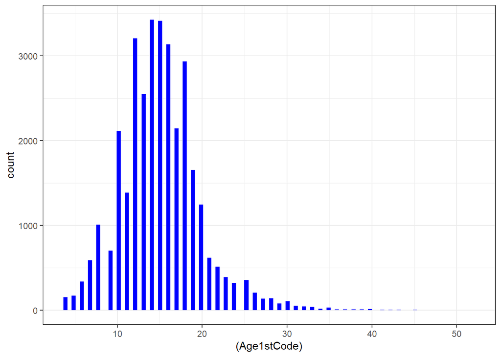

```r
ggplot(data,
       aes(x = (Age1stCode))) +
  geom_histogram(fill = "blue",
                 bins = 100) +
  theme_bw()
```

Let us focus on years of coding:

**Including any education, how many years have you been coding in total?**

```r
table(data$YearsCode)
```

```
##
##                  1                 10                 11                 12
##                188               2933               1150               1629
##                 13                 14                 15                 16
##               1054               1050               1841                888
##                 17                 18                 19                  2
##                776                823                489                475
##                 20                 21                 22                 23
##               1813                415                590                452
##                 24                 25                 26                 27
##                330                919                291                239
##                 28                 29                  3                 30
##                241                132                908                728
##                 31                 32                 33                 34
##                117                223                154                161
##                 35                 36                 37                 38
##                414                164                179                196
##                 39                  4                 40                 41
##                102               1205                341                 65
##                 42                 43                 44                 45
##                 76                 59                 42                 55
##                 46                 47                 48                 49
##                 22                 16                 17                  9
##                  5                 50                  6                  7
##               1870                 19               1912               1901
##                  8                  9   Less than 1 year More than 50 years
##               1997               1475                 70                 37
```

```r
sum(is.na(data$YearsCode))
```

```
## [1] 104
```

Let’s convert it into numerical one by censoring the data again, change NAs into median value and plot the distribution:

```r
data$YearsCode[data$YearsCode == "Less than 1 year"] <- 0
data$YearsCode[data$YearsCode == "More than 50 years"] <- 51
data$YearsCode <- as.numeric(data$YearsCode)
data$YearsCode[is.na(data$YearsCode)] <- median(data$YearsCode, na.rm =  TRUE)
```

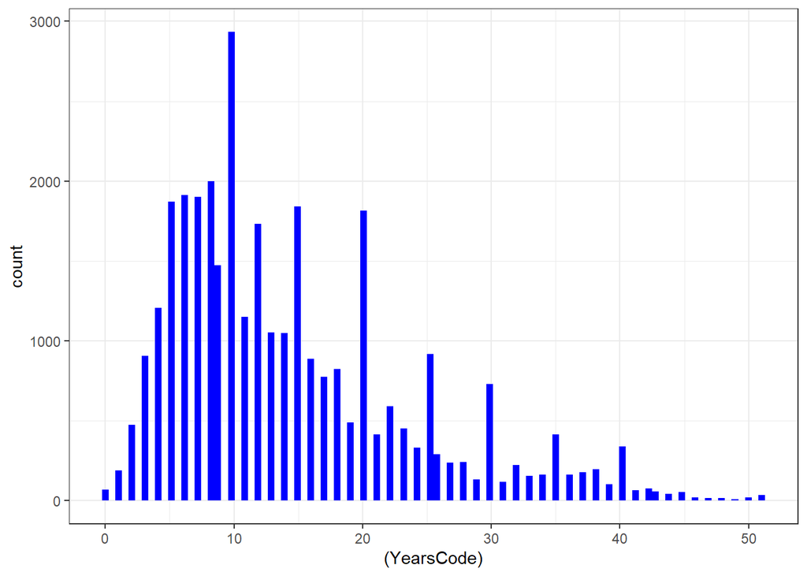

```r
ggplot(data,
       aes(x = (YearsCode))) +
  geom_histogram(fill = "blue",
                 bins = 100) +
  theme_bw()
```

**NOT including education, how many years have you coded professionally (as a part of your work)?**

```r
table(data$YearsCodePro)
```

```
##
##                  1                 10                 11                 12
##               1823               1970                752               1086
##                 13                 14                 15                 16
##                694                570               1094                473
##                 17                 18                 19                  2
##                340                385                283               3345
##                 20                 21                 22                 23
##               1008                277                326                238
##                 24                 25                 26                 27
##                183                391                136                108
##                 28                 29                  3                 30
##                 91                 53               3445                246
##                 31                 32                 33                 34
##                 59                 68                 64                 57
##                 35                 36                 37                 38
##                103                 36                 36                 48
##                 39                  4                 40                 41
##                 30               2662                 55                 12
##                 42                 43                 44                 45
##                 16                  9                  7                 12
##                 46                 47                 48                 49
##                  4                  3                  2                  1
##                  5                 50                  6                  7
##               2906                  4               2081               1675
##                  8                  9   Less than 1 year More than 50 years
##               1692                936               1338                 10
```

I will censor the data just like previously, change NAs to median and plot the distribution:

```r
data$YearsCodePro[data$YearsCodePro == "Less than 1 year"] <- 0
data$YearsCodePro[data$YearsCodePro == "More than 50 years"] <- 51
data$YearsCodePro <- as.numeric(data$YearsCodePro)
data$YearsCodePro[is.na(data$YearsCodePro)] <- median(data$YearsCodePro, na.rm =  TRUE)
```

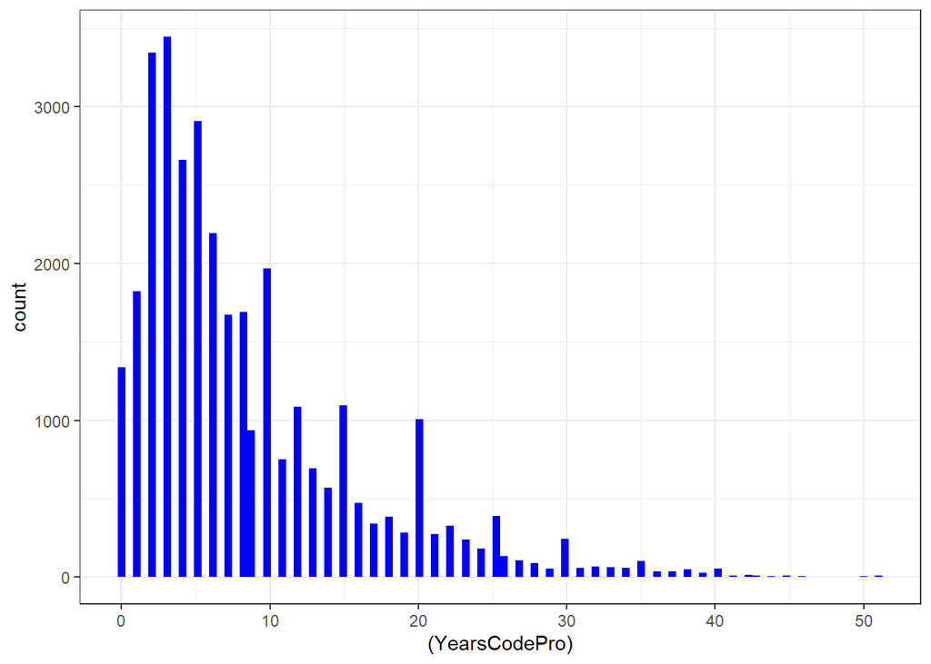

```r
ggplot(data,
       aes(x = (YearsCodePro))) +
  geom_histogram(fill = "blue",
                 bins = 100) +
  theme_bw()
```

I will make sure that there are no left NAs:

```r
colSums(is.na(data)) %>%
  sort()
```

```
##                         Respondent                         MainBranch
##                                  0                                  0
##                           Hobbyist                                Age
##                                  0                                  0
##                         Age1stCode                      ConvertedComp
##                                  0                                  0
##                            EdLevel                         Employment
##                                  0                                  0
##                             Gender                             JobSat
##                                  0                                  0
##                            JobSeek                          NEWEdImpt
##                                  0                                  0
##                           NEWLearn                        NEWOvertime
##                                  0                                  0
##                              OpSys                            OrgSize
##                                  0                                  0
##                       PurchaseWhat                          Sexuality
##                                  0                                  0
##                     UndergradMajor                        WorkWeekHrs
##                                  0                                  0
##                          YearsCode                       YearsCodePro
##                                  0                                  0
##                             Region                       Income.group
##                                  0                                  0
##                      DevType_count           DatabaseWorkedWith_count
##                                  0                                  0
##       LanguageDesireNextYear_count           LanguageWorkedWith_count
##                                  0                                  0
## NEWCollabToolsDesireNextYear_count     NEWCollabToolsWorkedWith_count
##                                  0                                  0
##       PlatformDesireNextYear_count           PlatformWorkedWith_count
##                                  0                                  0
```

And also see the summary of all the variables to make sure all of them have proper form (factor/count/binary):

```r
summary(data)
```

```
##    Respondent
##  Min.   :    8
##  1st Qu.:13174
##  Median :26230
##  Mean   :28938
##  3rd Qu.:47187
##  Max.   :65629
##                                                                          MainBranch
##  I am a developer by profession                                               :30339
##  I am not primarily a developer, but I write code sometimes as part of my work: 3017
##
##
##
##
##  Hobbyist             Age          Age1stCode   ConvertedComp
##  No : 7702   Unknown    : 2901   Min.   : 4.0   Min.   :      0
##  Yes:25654   student    : 6588   1st Qu.:12.0   1st Qu.:  25466
##              young-wolf :14282   Median :15.0   Median :  54049
##              middle-aged: 9585   Mean   :15.1   Mean   : 103706
##                                  3rd Qu.:18.0   3rd Qu.:  95126
##                                  Max.   :52.0   Max.   :2000000
##                            EdLevel                   Employment
##  1-No edu/primary/secondary/NAs: 2151   Employed full-time:29442
##  2-associate/without degree    : 5063   Other             : 3914
##  3-completed degree            :26142
##
##
##
##    Gender                                         JobSat
##  Man  :29317   Dissatisfied                          : 8209
##  other: 1774   Neither satisfied nor dissatisfied/NAs: 3903
##  Woman: 2265   Satisfied                             :21244
##
##
##
##                                                            JobSeek
##  I am actively looking for a job                               : 4311
##  I am not interested in new job opportunities                  : 9134
##  Iâ\200\231m not actively looking, but I am open to new opportunities:19668
##  Unknown                                                       :  243
```

[output cut: 50 more lines]

```
##  Max.   :25.000               Max.   :25.000
##  NEWCollabToolsDesireNextYear_count NEWCollabToolsWorkedWith_count
##  Min.   : 1.000                     Min.   : 1.000
##  1st Qu.: 2.000                     1st Qu.: 3.000
##  Median : 3.000                     Median : 4.000
##  Mean   : 3.272                     Mean   : 4.051
##  3rd Qu.: 4.000                     3rd Qu.: 5.000
##  Max.   :11.000                     Max.   :11.000
##  PlatformDesireNextYear_count PlatformWorkedWith_count
##  Min.   : 1.000               Min.   : 1.000
##  1st Qu.: 2.000               1st Qu.: 2.000
##  Median : 3.000               Median : 3.000
##  Mean   : 3.739               Mean   : 3.403
##  3rd Qu.: 5.000               3rd Qu.: 4.000
##  Max.   :16.000               Max.   :16.000
```

Let’s divide the explanatory variables into numeric and factor ones:

```r
data_numeric_vars <-
  sapply(data, is.numeric) %>%
  which() %>%
  names()

data_numeric_vars
```

```
##  [1] "Respondent"                         "Age1stCode"
##  [3] "ConvertedComp"                      "WorkWeekHrs"
##  [5] "YearsCode"                          "YearsCodePro"
##  [7] "DevType_count"                      "DatabaseWorkedWith_count"
##  [9] "LanguageDesireNextYear_count"       "LanguageWorkedWith_count"
## [11] "NEWCollabToolsDesireNextYear_count" "NEWCollabToolsWorkedWith_count"
## [13] "PlatformDesireNextYear_count"       "PlatformWorkedWith_count"
```

```r
data_factor_vars <-
  sapply(data, is.factor) %>%
  which() %>%
  names()

data_factor_vars
```

```
##  [1] "MainBranch"     "Hobbyist"       "Age"            "EdLevel"
##  [5] "Employment"     "Gender"         "JobSat"         "JobSeek"
##  [9] "NEWEdImpt"      "NEWLearn"       "NEWOvertime"    "OpSys"
## [13] "OrgSize"        "PurchaseWhat"   "Sexuality"      "UndergradMajor"
## [17] "Region"         "Income.group"
```

###Dependent variable

Once the explanatory variables are neat and tidy, let us focus on the dependent variable:

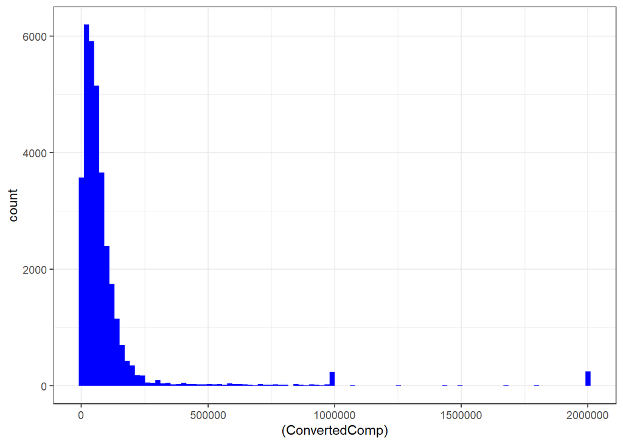

```r
ggplot(data,
       aes(x = (ConvertedComp))) +
  geom_histogram(fill = "blue",
                 bins = 100) +
  theme_bw()
```

The data is highly skewed. Moreover, there are a lot of misleading records(outliers). I will exclude the most unbelievable ones and check again the distribution of the variable both in normal and log form:

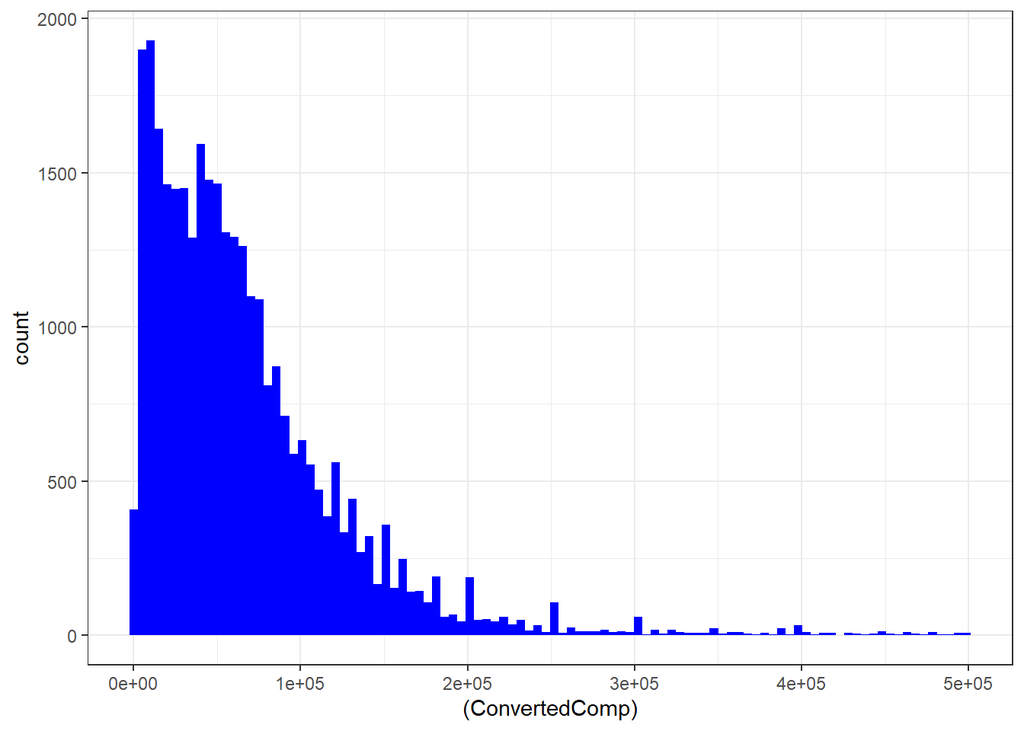

```r
data <- data[data$ConvertedComp > 500 & data$ConvertedComp < 500000,]



ggplot(data,
       aes(x = (ConvertedComp))) +
  geom_histogram(fill = "blue",
                 bins = 100) +
  theme_bw()
```

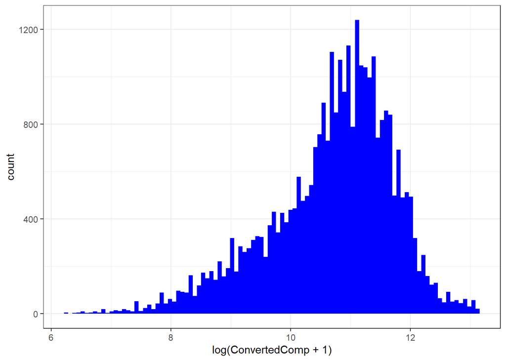

```r
ggplot(data,
       aes(x = log(ConvertedComp+1))) +
  geom_histogram(fill = "blue",
                 bins = 100) +
  theme_bw()
```

As the data is still highly skewed, I will stick to its log form while modeling.

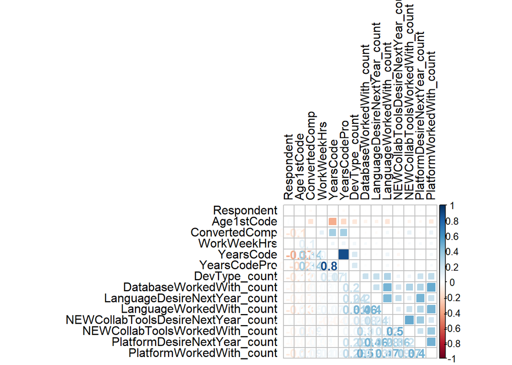

```r
data_correlations <-
  cor(data[,data_numeric_vars],
      use = "pairwise.complete.obs")





corrplot.mixed(data_correlations,
               upper = "square",
               lower = "number",
               tl.col="black",
               tl.pos = "lt")
```

Let’s prove whether there are any linear combinations between the numeric variables:

```r
( findLinearCombos(data[, data_numeric_vars] ) ->
    data_linearCombos )
```

```
## $linearCombos
## list()
##
## $remove
## NULL
```

No linear combinations.

Categorical variables: Let’s now apply the function written during classes sorting the categorical variables by F-statistic from anova test (the higher F-statistic, the stronger we reject the null hypothesis about lack of influence of the categorical variable on the outcome)

```r
data_F_anova <- function(categorical_var) {
  anova_ <- aov(data$ConvertedComp ~
                  data[[categorical_var]])

  return(summary(anova_)[[1]][1, 4])
}



sapply(data_factor_vars,
       data_F_anova) %>%
  sort(decreasing = TRUE) -> data_anova_all_categorical

data_anova_all_categorical
```

```
##   Income.group         Region            Age        OrgSize          OpSys
##   3706.9686813   2384.9626374    988.3172414    463.3895181    235.5483948
##        JobSeek         JobSat       NEWLearn UndergradMajor        EdLevel
##    233.1864496    175.2814109    102.9329699     83.9096565     59.0174303
##   PurchaseWhat     Employment      NEWEdImpt    NEWOvertime      Sexuality
##     48.7862656     28.9010297     23.0998431     22.6753410     20.2665600
##       Hobbyist         Gender     MainBranch
##      7.2692003      2.9093233      0.6483693
```

Let’s divide the dataset into traditional 70/30% partition:

```r
data_train_index <- createDataPartition(data$ConvertedComp,  p = 0.7,  list = FALSE)
data_train <- data[data_train_index,]
data_test <- data[-data_train_index,]



options(contrasts = c("contr.treatment",  # for non-ordinal factors
                      "contr.treatment")) # for ordinal factors
```

That is the end of ETL process. Let’s load the data to the models.

###Linear model

I will use OLS model as a benchmark for more complicated algorithms.

In this case I will use repeated cross validation with 5 folds and 3 repeats:

```r
ctrl_cv5x3 <- trainControl(method = "repeatedcv",
                            number = 5,
                            repeats = 3)

model_linear <-  train(log(ConvertedComp) ~ .,
                 data = data_train %>%
                 dplyr::select(-Respondent),
                  method = "lm",
                   trControl = ctrl_cv5x3)

model_linear
```

```
## Linear Regression
##
## 22357 samples
##    30 predictor
##
## No pre-processing
## Resampling: Cross-Validated (5 fold, repeated 3 times)
## Summary of sample sizes: 17885, 17886, 17885, 17886, 17886, 17886, ...
## Resampling results:
##
##   RMSE       Rsquared   MAE
##   0.6181287  0.6479147  0.4370088
##
## Tuning parameter 'intercept' was held constant at a value of TRUE
```

```r
summary(model_linear)
```

```
##
## Call:
## lm(formula = .outcome ~ ., data = dat)
##
## Residuals:
##     Min      1Q  Median      3Q     Max
## -5.4120 -0.3310 -0.0011  0.3137  4.0589
##
## Coefficients:
##                                                                                             Estimate
## (Intercept)                                                                                9.0259304
## `MainBranchI am not primarily a developer, but I write code sometimes as part of my work` -0.0660931
## HobbyistYes                                                                                0.0248219
## Agestudent                                                                                -0.2311445
## `Ageyoung-wolf`                                                                            0.0709082
## `Agemiddle-aged`                                                                           0.0903488
## Age1stCode                                                                                -0.0103350
## `EdLevel2-associate/without degree`                                                        0.0579550
## `EdLevel3-completed degree`                                                                0.2066480
## EmploymentOther                                                                           -0.3361874
## Genderother                                                                                0.0445901
## GenderWoman                                                                               -0.0574774
## `JobSatNeither satisfied nor dissatisfied/NAs`                                            -0.0578695
## JobSatSatisfied                                                                            0.0344442
## `JobSeekI am not interested in new job opportunities`                                      0.1215860
## `JobSeekIâ\\200\\231m not actively looking, but I am open to new opportunities`            0.0576823
## JobSeekUnknown                                                                            -0.0540349
## `NEWEdImptSomewhat important/Fairly important`                                            -0.0610743
## `NEWEdImptVery/Critically important`                                                      -0.0888875
## `NEWLearnOnce a decade`                                                                    0.1096836
## `NEWLearnOnce a year`                                                                      0.1569143
## `NEWLearnOnce every few years`                                                             0.1695678
## `NEWLearnEvery few months`                                                                 0.1121073
## `NEWOvertimeOccasionally/Sometimes`                                                        0.0441826
## `NEWOvertimeOften: 1-2 days per week or more`                                              0.0104212
## `OpSysLinux-based`                                                                         0.1207315
## OpSysMacOS                                                                                 0.2386787
## OpSysWindows                                                                               0.0332884
## `OrgSizeup to 99 employees`                                                                0.0055576
## `OrgSize100 to 999 employees`                                                              0.1768934
```

[output cut: 235 more lines]

```
## `Income.groupHigh income`                                                                 ***
## DevType_count                                                                             ***
## DatabaseWorkedWith_count
## LanguageDesireNextYear_count                                                              **
## LanguageWorkedWith_count                                                                  *
## NEWCollabToolsDesireNextYear_count                                                        .
## NEWCollabToolsWorkedWith_count                                                            ***
## PlatformDesireNextYear_count
## PlatformWorkedWith_count                                                                  ***
## ---
## Signif. codes:  0 '***' 0.001 '**' 0.01 '*' 0.05 '.' 0.1 ' ' 1
##
## Residual standard error: 0.6171 on 22303 degrees of freedom
## Multiple R-squared:  0.6499, Adjusted R-squared:  0.6491
## F-statistic: 781.3 on 53 and 22303 DF,  p-value: < 2.2e-16
```

Judging by the p-value of F-test we may see that all coefficients are jointly significant. No wonder - coefficients standing next to almost all variables are significant on high levels.

###KNN

By trial and error methods I estimated that the optimal k-parameter value is around 25. One has to remember, that the explanatory variables have to be scaled, I will use “range” method for that:

```r
ctrl_cv5x3 <- trainControl(method = "repeatedcv",
                            number = 5,
                            repeats = 3)


different_k <- data.frame(k = 25)

model_knn <-
  train(log(ConvertedComp) ~ .,
        data = data_train %>%

          dplyr::select(-Respondent),

        method = "knn",

        trControl = ctrl_cv5x3,


        preProcess = c("range"),
        tuneGrid = different_k)


model_knn
```

```
## k-Nearest Neighbors
##
## 22357 samples
##    30 predictor
##
## Pre-processing: re-scaling to [0, 1] (53)
## Resampling: Cross-Validated (5 fold, repeated 3 times)
## Summary of sample sizes: 17886, 17886, 17886, 17885, 17885, 17885, ...
## Resampling results:
##
##   RMSE       Rsquared   MAE
##   0.6621699  0.6043236  0.4704258
##
## Tuning parameter 'k' was held constant at a value of 25
```

###Random forest

“Ranger” method is used in order to process random forest and tuneLentgh determined as a default in order to obtain faster computation. This time I won’t use repeated cross validation method for this reason as well:

```r
ctrl_cv10 <- trainControl(method = "cv",
                          number = 5)

model_RF <-   train(log(ConvertedComp) ~ .,
             data = data_train %>%
               dplyr::select(-Respondent),
              method = "ranger",
              trControl = ctrl_cv10 )
model_RF
```

```
## Random Forest
##
## 22357 samples
##    30 predictor
##
## No pre-processing
## Resampling: Cross-Validated (5 fold)
## Summary of sample sizes: 17885, 17886, 17886, 17886, 17885
## Resampling results across tuning parameters:
##
##   mtry  splitrule   RMSE       Rsquared   MAE
##    2    variance    0.6523476  0.6595564  0.4698741
##    2    extratrees  0.6699149  0.6445062  0.4845913
##   27    variance    0.5940459  0.6749047  0.4140664
##   27    extratrees  0.5968175  0.6719984  0.4173858
##   53    variance    0.5989867  0.6693645  0.4182794
##   53    extratrees  0.5970065  0.6716241  0.4171066
##
## Tuning parameter 'min.node.size' was held constant at a value of 5
## RMSE was used to select the optimal model using the smallest value.
## The final values used for the model were mtry = 27, splitrule = variance
##  and min.node.size = 5.
```

###Performance measures

To compare the results on the test sample I will use the function written during labs:

```r
regressionMetrics <- function(real, predicted) {
  # Mean Square Error
  MSE <- mean((real - predicted)^2)
  # Root Mean Square Error
  RMSE <- sqrt(MSE)
  # Mean Absolute Error
  MAE <- mean(abs(real - predicted))
  # Mean Absolute Percentage Error
  MAPE <- mean(abs(real - predicted)/real)
  # Median Absolute Error
  MedAE <- median(abs(real - predicted))
  # Mean Logarithmic Absolute Error
  MSLE <- mean((log(1 + real) - log(1 + predicted))^2)
  # Total Sum of Squares
  TSS <- sum((real - mean(real))^2)
  # Residual Sum of Squares
  RSS <- sum((predicted - real)^2)
  # R2
  R2 <- 1 - RSS/TSS

  result <- data.frame(MSE, RMSE, MAE, MAPE, MedAE, MSLE, R2)
  return(result)
}


regressionMetrics(real = log(data_test$ConvertedComp),
                  predicted = predict(model_linear, data_test))
```

```
##         MSE      RMSE      MAE       MAPE     MedAE        MSLE        R2
## 1 0.3623055 0.6019182 0.433063 0.04205231 0.3255088 0.002932495 0.6678041
```

```r
regressionMetrics(real = log(data_test$ConvertedComp),
                  predicted = predict(model_knn, data_test))
```

```
##         MSE    RMSE       MAE       MAPE     MedAE        MSLE        R2
## 1 0.4233064 0.65062 0.4697679 0.04614207 0.3440519 0.003465028 0.6118727
```

```r
regressionMetrics(real = log(data_test$ConvertedComp),
                  predicted = predict(model_RF, data_test))
```

```
##         MSE      RMSE       MAE       MAPE     MedAE       MSLE        R2
## 1 0.3322788 0.5764363 0.4093606 0.03969767 0.3021355 0.00268228 0.6953354
```

### Conclusions

The performance measures obtained on the test sample don’t differ much. However the best results gives random forest algortihm, the 2nd one is OLS model and then K-nn method with parameter set to 25.

###Refrences

1)Lab materials - R scripts and presentations

2)https://www.kaggle.com/boss0ayush/salary-survey-data

3)https://www.rdocumentation.org/

4)https://stackoverflow.com/